# Statistics: The Science of Decisions Project Instructions

**Background Information**

In a Stroop task, participants are presented with a list of words, with each word displayed in a color of ink. The participant’s task is to say out loud the color of the ink in which the word is printed. The task has two conditions: a congruent words condition, and an incongruent words condition. In the congruent words condition, the words being displayed are color words whose names match the colors in which they are printed: for example RED, BLUE. In the incongruent words condition, the words displayed are color words whose names do not match the colors in which they are printed: for example PURPLE, ORANGE. In each case, we measure the time it takes to name the ink colors in equally-sized lists. Each participant will go through and record a time from each condition. Questions For Investigation

As a general note, be sure to keep a record of any resources that you use or refer to in the creation of your project. You will need to report your sources as part of the project submission.

1. What is our independent variable? What is our dependent variable?

**Answer**:

Independent variables do not change based on other factors we are trying to measure. In our case word condition i.e. incongruent or congruent test would be the independent variables which influence the dependent variable i.e the time taken by each person to name the color of the ink in which the word is written. Hence in our case here, the test or the word condition (congruent or incongruent would be the independent variable) and the time taken for each subject to name the color of the ink in which the word is written would be the dependent variable.

1. What is an appropriate set of hypotheses for this task? What kind of statistical test do you expect to perform? Justify your choices.

**Answer**: We need to performe two tailed hypotheses test. Lets consider the population mean as μ and the sample mean as $\bar{x}$. We have been provided 24 paired samples from a population. The hypotheses we are testing is to infer some understanidng about the population based on the sample provided to us. $\mu0$ = population mean with congruent test. $\mu$ = population mean with incongruent test.

Mathematical representation for this Null Hypotheses would be $\mu0 = \mu$ and the Alternate Hypotheses would be $\mu0 \neq \mu$

Null Hypotheses: There is no significant difference between the time taken in the congruent test and incongruent test.

Alternative Hypotheses: Time taken by the Incongruent test is significantly different than time taken by the congruent test.

We are going to perform dependent/paired T test for this example. the reasons fro that are:

1. The sample size is much smaller i.e. < 30 hence T test is more reliable with the assumption that the data is approximately normally distributed.
2. We dont know the population standard deviation which is a big factor in using the T test analysis.
3. The samples provided are given from same people for two different tests, we are to compare the results of the two tests for same set of people. For such kind of comparison we do the paired T-test.

Now it’s your chance to try out the Stroop task for yourself. Go to this link, which has a Java-based applet for performing the Stroop task. Record the times that you received on the task (you do not need to submit your times to the site.) Now, download this dataset which contains results from a number of participants in the task. Each row of the dataset contains the performance for one participant, with the first number their results on the congruent task and the second number their performance on the incongruent task.

```python
%matplotlib inline
import csv
from datetime import datetime
import numpy as np
import pandas as pd
from IPython.display import display
import matplotlib.pyplot as plt
import seaborn as sns

sample_data = pd.read_csv('stroopdata.csv')
difference_data = sample_data['Incongruent']-sample_data['Congruent']
#sample_data.insert(difference_data, axis=1)
display(sample_data)
```

|  | Congruent | Incongruent |
| --- | --- | --- |
| 0 | 12.079 | 19.278 |
| 1 | 16.791 | 18.741 |
| 2 | 9.564 | 21.214 |
| 3 | 8.630 | 15.687 |
| 4 | 14.669 | 22.803 |
| 5 | 12.238 | 20.878 |
| 6 | 14.692 | 24.572 |
| 7 | 8.987 | 17.394 |
| 8 | 9.401 | 20.762 |
| 9 | 14.480 | 26.282 |
| 10 | 22.328 | 24.524 |
| 11 | 15.298 | 18.644 |
| 12 | 15.073 | 17.510 |
| 13 | 16.929 | 20.330 |
| 14 | 18.200 | 35.255 |
| 15 | 12.130 | 22.158 |
| 16 | 18.495 | 25.139 |
| 17 | 10.639 | 20.429 |
| 18 | 11.344 | 17.425 |
| 19 | 12.369 | 34.288 |
| 20 | 12.944 | 23.894 |
| 21 | 14.233 | 17.960 |
| 22 | 19.710 | 22.058 |
| 23 | 16.004 | 21.157 |

|  | Congruent | Incongruent |
| --- | --- | --- |
| count | 24.000000 | 24.000000 |
| mean | 14.051125 | 22.015917 |
| std | 3.559358 | 4.797057 |
| min | 8.630000 | 15.687000 |
| 25% | 11.895250 | 18.716750 |
| 50% | 14.356500 | 21.017500 |
| 75% | 16.200750 | 24.051500 |
| max | 22.328000 | 35.255000 |

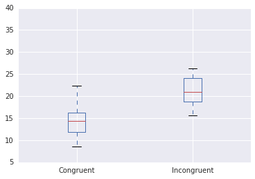

```python
df = pd.DataFrame(sample_data)


df.plot.box()
#plt.show()
sample_data.describe()
```

1. Report some descriptive statistics regarding this dataset. Include at least one measure of central tendency and at least one measure of variability.

**Answer**: Some statistics of the data are shown above. We have printed the mean, median and number of data points as measure of central tendency and standard deviation as the measure of variability. from the breakdown we can see that the average for incongruency test is higher than congruency test. we need to do further analysis to see if this is significant difference. the std dev for incongruency test is higher than congruency test as well, indication a higher sread in values for incongruency test than congruency test.

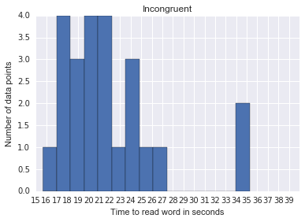

[figure not shown]

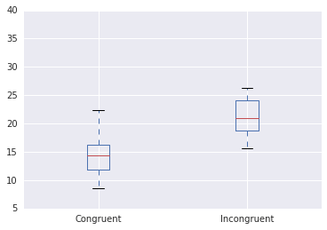

```python
plt.hist(df['Incongruent'],bins = 15)
plt.xticks(np.arange(15,40))
plt.title('Incongruent')
plt.xlabel('Time to read word in seconds')
plt.ylabel("Number of data points")
plt.show()
#plt.title("Number of".format(key_name))
#df['Incongruent'].plot()
#plt.show()

plt.hist(df['Congruent'],bins = 10)
plt.xticks(np.arange(8,25))
plt.title('Incongruent')
plt.xlabel('Time to read word in seconds')
plt.ylabel("Number of data points")
plt.show()
#df['Congruent'].plot()
#plt.show()

#difference_data.plot.hist()
#plt.xlabel('Congruent')
#plt.ylabel("Time duration")
#plt.show()

df.plot.box()
```

1. Provide one or two visualizations that show the distribution of the sample data. Write one or two sentences noting what you observe about the plot or plots.

1. Now, perform the statistical test and report your results. What is your confidence level and your critical statistic value? Do you reject the null hypothesis or fail to reject it? Come to a conclusion in terms of the experiment task. Did the results match up with your expectations?

**Answer**: Statistical analysis:

I have performed the statistical analysis below using excel sheets and p value table.

alpha 0.05 cohens d -1.637219949 T stat  
-8.0207 8.0207  
T crit  
-2.069 2.069

```
p value    < 0.0001
```

We reject the null hypotheses

```
Confidence interval    Md +- (t crit*SE)
```

-5.910274667 -10.01930867

Based on the analysis above I have to reject the null hypotheses. Since the p value is less than 0.0001 we can say that the fact that mean of incongruency test is higher than congruency test is not an anomaly. the incongruency test has a measureable effect on the test takers.The observed data is singinificantly unlikely if the null hypothese is true.

Yes the results matched upto my expectation. We can get an idea based on the descriptive statistics we saw above that there was some difference between the results of the congruency test and the incongruency test. the inferential statistics that using t statistics givens us more confidence in this assumptions that the difference between the data is significant for rejecting the null hypotheses.

1. Optional: What do you think is responsible for the effects observed? Can you think of an alternative or similar task that would result in a similar effect? Some research about the problem will be helpful for thinking about these two questions!

The two theories that might be the cause of this particular effect :

Speed of Processing Theory: the interference occurs because words are read faster than colors are named. Selective Attention Theory: the interference occurs because naming colors requires more attention than reading words.

A similar task could be when actors are playing parts in a movie or stage with someone they have known a long time. they associate the name to the person, so it might be difficult to switch between the stage name and real name of the person.